# Pretransplant natural antibody levels identify a subset of deceased donor kidney transplant recipients that benefit from infliximab induction

### 9.1.2 Models

#### 9.1.2.1 Main effects models

**Open code**

```r
model_GFR_MDRD_3_GPL_BC_main <- run(
  expr = brm_multiple(
    GFR_MDRD_3 ~
      male_sex +
      I(rec_age - 50) +
      male_sex_donor +
      I(KDPI - 50) +
      I(CIT - 15) +
      I(HLA_MM - 5) +
      perfusion_event +
      infliximab +
      GPL_BC_log2,
    family = student(),
    data = data_imputed,
    prior = priors_main,
    backend = "cmdstanr",
    seed = 2025,
    cores = 4, chains = 4,
    iter = 2000, warmup = 1900,
    control = list(adapt_delta = 0.95)
  ),
  path = "gitignore/run/model_GFR_MDRD_3_GPL_BC_main",
  reuse = TRUE
)

summary(model_GFR_MDRD_3_GPL_BC_main, robust = TRUE)
## Warning: Parts of the model have not converged (some Rhats are > 1.05). Be
## careful when analysing the results! We recommend running more iterations and/or
## setting stronger priors.
##  Family: student
##   Links: mu = identity; sigma = identity; nu = identity
## Formula: GFR_MDRD_3 ~ male_sex + I(rec_age - 50) + male_sex_donor + I(KDPI - 50) + I(CIT - 15) + I(HLA_MM - 5) + perfusion_event + infliximab + GPL_BC_log2
##    Data: data_imputed (Number of observations: 177)
##   Draws: 320 chains, each with iter = 2000; warmup = 1900; thin = 1;
##          total post-warmup draws = 32000
##
## Regression Coefficients:
##                 Estimate Est.Error l-95% CI u-95% CI Rhat Bulk_ESS Tail_ESS
## Intercept          53.13      4.10    45.10    61.27 1.01    16406    26395
## male_sex            1.79      3.27    -4.58     8.15 1.01    38414    27869
## Irec_ageM50         0.02      0.15    -0.28     0.32 1.01    37809    27823
## male_sex_donor      0.90      3.20    -5.44     7.24 1.01    38901    27640
## IKDPIM50           -0.24      0.08    -0.40    -0.09 1.01    36390    28400
## ICITM15             0.28      0.23    -0.17     0.72 1.02     9808    27230
## IHLA_MMM5          -0.74      1.09    -2.93     1.42 1.06     3247    11176
## perfusion_event    -6.16      3.55   -13.10     0.87 1.06     3134    15250
## infliximab         -2.12      3.18    -8.29     4.13 1.01    38526    28245
## GPL_BC_log2         0.26      1.11    -1.96     2.46 1.01    39429    27240
##
## Further Distributional Parameters:
##       Estimate Est.Error l-95% CI u-95% CI Rhat Bulk_ESS Tail_ESS
## sigma    18.99      1.38    16.21    21.76 1.01    28098    22430
## nu       15.72      9.37     5.22    50.79 1.00    28333    25429
##
## Draws were sampled using sample(hmc). For each parameter, Bulk_ESS
## and Tail_ESS are effective sample size measures, and Rhat is the potential
## scale reduction factor on split chains (at convergence, Rhat = 1).
prior_summary(model_GFR_MDRD_3_GPL_BC_main)
##                          prior     class            coef group resp dpar nlpar
##                         (flat)         b
##    normal(0, 632.741442420408)         b     GPL_BC_log2
##    normal(0, 5.93437623501858)         b         ICITM15
##    normal(0, 29.2623385998383)         b       IHLA_MMM5
##    normal(0, 2.05566141844214)         b        IKDPIM50
##    normal(0, 84.6839516288788)         b      infliximab
##    normal(0, 4.03497355002315)         b     Irec_ageM50
##    normal(0, 84.6839516288788)         b        male_sex
##    normal(0, 84.6839516288788)         b  male_sex_donor
##    normal(0, 84.6839516288788)         b perfusion_event
##  normal(51.7227118644068, 200) Intercept
##                  gamma(2, 0.1)        nu
##          student_t(3, 0, 19.7)     sigma
##  lb ub  source
##        default
##           user
##           user
##           user
##           user
##           user
##           user
##           user
##           user
##           user
##           user
##   1    default
##   0    default

tr <- round(fixef(model_GFR_MDRD_3_GPL_BC_main, robust = TRUE)[-1, c(1,3,4)], 2)
colnames(tr)[1] <- 'Estimate'
kableExtra::kable(tr)
```

Table 17: Results from multivariable Bayesian robust regression model examining the main effects of predictors, including `infliximab` treatment and log2-transformed anti-cardiolipin IgG (`GPL_BC_log2`), on estimated glomerular filtration rate (eGFR), without interaction terms. `Estimate` represents the estimated change in eGFR per one-unit increase in the predictor. `Q2.5` and `Q97.5`: lower and upper bounds of the 95% credible interval, respectively.

|  | Estimate | Q2.5 | Q97.5 |
| --- | --- | --- | --- |
| male_sex | 1.79 | -4.58 | 8.15 |
| Irec_ageM50 | 0.02 | -0.28 | 0.32 |
| male_sex_donor | 0.90 | -5.44 | 7.24 |
| IKDPIM50 | -0.24 | -0.40 | -0.09 |
| ICITM15 | 0.28 | -0.17 | 0.72 |
| IHLA_MMM5 | -0.74 | -2.93 | 1.42 |
| perfusion_event | -6.16 | -13.10 | 0.87 |
| infliximab | -2.12 | -8.29 | 4.13 |
| GPL_BC_log2 | 0.26 | -1.96 | 2.46 |

#### 9.1.2.2 Non-linear interaction model

**Open code**

```r
model_GFR_MDRD_3_GPL_BC_interaction_NL <- run(
  expr = brm_multiple(
    GFR_MDRD_3 ~
    male_sex +
    I(rec_age - 50) +
    male_sex_donor +
    I(KDPI - 50) +
    I(CIT - 15) +
    I(HLA_MM - 5) +
    perfusion_event +
    infliximab +
    s(GPL_BC_log2, bs = 'ps', k = 5) +
    s(GPL_BC_log2, by = infliximab, bs = 'ps', k = 5),
    family = student(),
    data = data_imputed,
    prior = priors_interaction_pnl,
    backend = "cmdstanr",
    seed = 2025,
    cores = 4, chains = 4,
    iter = 2000, warmup = 1900,
    control = list(adapt_delta = 0.95)
  ),
  path = "gitignore/run/model_GFR_MDRD_3_GPL_BC_interaction_NL",
  reuse = TRUE
)

summary(model_GFR_MDRD_3_GPL_BC_interaction_NL, robust = TRUE)
## Warning: Parts of the model have not converged (some Rhats are > 1.05). Be
## careful when analysing the results! We recommend running more iterations and/or
## setting stronger priors.
## Warning: There were 2 divergent transitions after warmup. Increasing
## adapt_delta above 0.95 may help. See
## http://mc-stan.org/misc/warnings.html#divergent-transitions-after-warmup
##  Family: student
##   Links: mu = identity; sigma = identity; nu = identity
## Formula: GFR_MDRD_3 ~ male_sex + I(rec_age - 50) + male_sex_donor + I(KDPI - 50) + I(CIT - 15) + I(HLA_MM - 5) + perfusion_event + infliximab + s(GPL_BC_log2, bs = "ps", k = 5) + s(GPL_BC_log2, by = infliximab, bs = "ps", k = 5)
##    Data: data_imputed (Number of observations: 177)
##   Draws: 320 chains, each with iter = 2000; warmup = 1900; thin = 1;
##          total post-warmup draws = 32000
##
## Smoothing Spline Hyperparameters:
##                               Estimate Est.Error l-95% CI u-95% CI Rhat
## sds(sGPL_BC_log2_1)              10.58      7.05     0.88    34.65 1.01
## sds(sGPL_BC_log2infliximab_1)     4.20      3.89     0.20    19.80 1.01
##                               Bulk_ESS Tail_ESS
## sds(sGPL_BC_log2_1)              16287    11879
## sds(sGPL_BC_log2infliximab_1)    33049    17349
##
## Regression Coefficients:
##                           Estimate Est.Error l-95% CI u-95% CI Rhat Bulk_ESS
## Intercept                    54.18      4.05    46.38    62.11 1.01    18434
## male_sex                      1.08      3.19    -5.20     7.36 1.01    47958
## Irec_ageM50                   0.03      0.15    -0.27     0.32 1.01    45592
## male_sex_donor               -0.61      3.23    -6.93     5.76 1.01    46094
## IKDPIM50                     -0.25      0.08    -0.41    -0.09 1.01    43069
## ICITM15                       0.28      0.22    -0.16     0.72 1.02    13311
## IHLA_MMM5                    -0.91      1.08    -3.06     1.23 1.06     3272
## perfusion_event              -5.86      3.48   -12.66     0.90 1.05     3684
## infliximab                    0.18     81.74  -161.71   162.22 1.01    14656
## sGPL_BC_log2_1               15.85     14.73   -15.35    57.10 1.01    24674
## sGPL_BC_log2:infliximab_1   -16.62     46.80  -110.53    75.97 1.01    14735
## sGPL_BC_log2:infliximab_2    13.23     29.32   -45.55    71.28 1.01    14950
##                           Tail_ESS
## Intercept                    29314
## male_sex                     26709
## Irec_ageM50                  26752
## male_sex_donor               27159
## IKDPIM50                     27230
## ICITM15                      26250
## IHLA_MMM5                    13786
## perfusion_event              14214
## infliximab                   19615
## sGPL_BC_log2_1               19574
## sGPL_BC_log2:infliximab_1    19281
## sGPL_BC_log2:infliximab_2    19912
##
## Further Distributional Parameters:
##       Estimate Est.Error l-95% CI u-95% CI Rhat Bulk_ESS Tail_ESS
## sigma    18.49      1.39    15.60    21.23 1.01    30097    21798
## nu       15.01      9.04     4.92    49.64 1.00    33096    25294
##
## Draws were sampled using sample(hmc). For each parameter, Bulk_ESS
## and Tail_ESS are effective sample size measures, and Rhat is the potential
## scale reduction factor on split chains (at convergence, Rhat = 1).
prior_summary(model_GFR_MDRD_3_GPL_BC_interaction_NL)
##                          prior     class
##                         (flat)         b
##    normal(0, 5.93437623501858)         b
##    normal(0, 29.2623385998383)         b
##    normal(0, 2.05566141844214)         b
##    normal(0, 84.6839516288788)         b
##    normal(0, 4.03497355002315)         b
##    normal(0, 84.6839516288788)         b
##    normal(0, 84.6839516288788)         b
##    normal(0, 84.6839516288788)         b
##                         (flat)         b
##                         (flat)         b
##                         (flat)         b
##  normal(51.7227118644068, 200) Intercept
##                  gamma(2, 0.1)        nu
##          student_t(3, 0, 19.7)       sds
##            student_t(3, 0, 12)       sds
##             student_t(3, 0, 6)       sds
##          student_t(3, 0, 19.7)     sigma
##                                               coef group resp dpar nlpar lb ub
##
##                                            ICITM15
##                                          IHLA_MMM5
##                                           IKDPIM50
##                                         infliximab
##                                        Irec_ageM50
##                                           male_sex
##                                     male_sex_donor
##                                    perfusion_event
##                                     sGPL_BC_log2_1
##                          sGPL_BC_log2:infliximab_1
##                          sGPL_BC_log2:infliximab_2
##
##                                                                           1
##                                                                           0
##                   s(GPL_BC_log2, bs = "ps", k = 5)                        0
##  s(GPL_BC_log2, by = infliximab, bs = "ps", k = 5)                        0
##                                                                           0
##        source
##       default
##          user
##          user
##          user
##          user
##          user
##          user
##          user
##          user
##  (vectorized)
##  (vectorized)
##  (vectorized)
##          user
##       default
##       default
##          user
##          user
##       default

tr2 <- round(fixef(model_GFR_MDRD_3_GPL_BC_interaction_NL,
                       robust = TRUE)[-c(1,9:12), c(1,3,4)], 2)

antibody_seq <- quantile(data_model_priorImpute$GPL_BC_log2,
                         probs = c(0.05, 0.95))

asl <- length(antibody_seq)
quant_dif <- antibody_seq[2] - antibody_seq[1]

data_prediction <- data.frame(
    male_sex = rep(mmale_sex, 2*length(antibody_seq)),
  `male_sex_donor` = rep(mmale_sex_donor, 2*length(antibody_seq)),
  `perfusion_event` = rep(mperfusion_event, 2*length(antibody_seq)),
  `infliximab` = c(rep(0, length(antibody_seq)), rep(1, length(antibody_seq))),
  `rec_age` = rep(mrec_age, 2*length(antibody_seq)),
  `KDPI` = rep(mKDPI, 2*length(antibody_seq)),
  `CIT` = rep(mCIT, 2*length(antibody_seq)),
  `HLA_MM` = rep(mHLA_MM, 2*length(antibody_seq)),
  `GPL_BC_log2` = c(antibody_seq, antibody_seq)
  )

tr <-  posterior_epred(
    model_GFR_MDRD_3_GPL_BC_interaction_NL,
    newdata = data_prediction)

prediction_ctrl <- tr[, c(1:asl)]
prediction_infliximab <- tr[, c((asl+1):(asl*2))]

## get Estimate for infliximab effect across antibody values
prediction <- (
  prediction_infliximab-
     prediction_ctrl
  ) %>% data.frame()

names(prediction) <- c('p05', 'p95')

infliximab_GPL_BC_log2_int <- quantile(
  (prediction$p95 - prediction$p05)/scaling_unit,
         probs = c(0.5, 1/40, 39/40))

tr2 <- rbind(tr2, round(infliximab_GPL_BC_log2_int, 2))
row.names(tr2)[8] <- 'infliximab:GPL_BC_log2'
kableExtra::kable(tr2)
```

Table 18: Results from a multivariable Bayesian robust regression model incorporating a non-linear interaction between anti-cardiolipin IgG (`GPL_BC_log2`) and `infliximab` treatment on estimated glomerular filtration rate (eGFR), while accounting for other covariates. `Estimate` represents the estimated change in eGFR per one-unit increase in the predictor. The last row (`infliximab:GPL_BC_log2`) reports the difference in infliximab’s treatment effect at the 95th versus the 5th percentile of anti-cardiolipin IgG, quantifying the interaction effect. `Q2.5` and `Q97.5`: lower and upper bounds of the 95% credible interval, respectively.

|  | Estimate | Q2.5 | Q97.5 |
| --- | --- | --- | --- |
| male_sex | 1.08 | -5.20 | 7.36 |
| Irec_ageM50 | 0.03 | -0.27 | 0.32 |
| male_sex_donor | -0.61 | -6.93 | 5.76 |
| IKDPIM50 | -0.25 | -0.41 | -0.09 |
| ICITM15 | 0.28 | -0.16 | 0.72 |
| IHLA_MMM5 | -0.91 | -3.06 | 1.23 |
| perfusion_event | -5.86 | -12.66 | 0.90 |
| infliximab:GPL_BC_log2 | -23.24 | -42.13 | -4.18 |

### 9.1.3 Visualisation - penalized non-linear effect

Extract posterior draws

**Open code**

```r
antibody_perc <- quantile(data_model_priorImpute$GPL_BC_log2,
                           probs = c(0, 0.02, 0.05, 0.25, 0.5, 0.75, 0.95, 0.98, 1))

antibody_seq <- seq(antibody_perc[1],
                      antibody_perc[length(antibody_perc)],
                      length.out = 101)

## create prediction
data_prediction <- data.frame(
    male_sex = rep(mmale_sex, 2*length(antibody_seq)),
  `male_sex_donor` = rep(mmale_sex_donor, 2*length(antibody_seq)),
  `perfusion_event` = rep(mperfusion_event, 2*length(antibody_seq)),
  `infliximab` = c(rep(0, length(antibody_seq)), rep(1, length(antibody_seq))),
  `rec_age` = rep(mrec_age, 2*length(antibody_seq)),
  `KDPI` = rep(mKDPI, 2*length(antibody_seq)),
  `CIT` = rep(mCIT, 2*length(antibody_seq)),
  `HLA_MM` = rep(mHLA_MM, 2*length(antibody_seq)),
  `GPL_BC_log2` = c(antibody_seq, antibody_seq)
  )

prediction <- data.frame(
  posterior_epred(
    model_GFR_MDRD_3_GPL_BC_interaction_NL,
    newdata = data_prediction) %>% posterior_summary(
      robust = TRUE
      ) %>% data.frame() %>% select(-Est.Error),
  group = factor(if_else(data_prediction$infliximab == 1, 'infliximab', 'control')),
  GPL_BC_log2 = data_prediction$GPL_BC_log2)
```

Figure A

**Open code**

```r
cole <- c('#CD7006', '#0028F0')

fig_a <- prediction %>%
  mutate(group = factor(group, levels = c("infliximab", "control")),
         `Q2.5` = if_else(`Q2.5` < 0, 0, `Q2.5`)) %>%
  ggplot(aes(x = GPL_BC_log2, y = Estimate, col = group, fill = group)) +
  geom_line(aes(y = Estimate), linewidth = 1) +
  scale_y_continuous(limits = c(0, 125),
                      breaks = c(seq(0, 125, by = 25))) +

  geom_ribbon(aes(ymin = `Q2.5`, ymax = `Q97.5`),
               alpha = 0.4,  color = NA) +

  geom_point(data = data_model_priorImpute,
             aes(x = GPL_BC_log2, y = GFR_MDRD_3, col = group, fill = group)) +

  labs(x = expression(log[2]~"(aCL IgG ["*mu*"g/ml])"),
       y = "GFR (mL/min/1.73 m²)") +

  scale_color_manual(values = cole,
                       name = "group",
                       breaks = c('control', 'infliximab'),
                       labels = c('control', 'infliximab')) +

  scale_fill_manual(values = cole,
                       name = "group",
                       breaks = c('control', 'infliximab'),
                       labels = c('control', 'infliximab')) +

  facet_grid(rows = vars(group)) +

  theme(axis.text=element_text(size = 10),
        axis.title=element_text(size = 12),
        strip.text.x = element_text(size = 12),
        legend.position = "none") +

  geom_vline(xintercept = antibody_perc[3:7], linetype = 2,
                            color = "grey50", size = 0.3)
```

Figure B

**Open code**

```r
antibody_seq <- antibody_perc[c(3, 7)]
antibody_seq
##        5%       95%
## -1.801668  2.531821

data_prediction <- data.frame(
   male_sex = rep(mmale_sex, 2*length(antibody_seq)),
  `male_sex_donor` = rep(mmale_sex_donor, 2*length(antibody_seq)),
  `perfusion_event` = rep(mperfusion_event, 2*length(antibody_seq)),
  `infliximab` = c(rep(0, length(antibody_seq)), rep(1, length(antibody_seq))),
  `rec_age` = rep(mrec_age, 2*length(antibody_seq)),
  `KDPI` = rep(mKDPI, 2*length(antibody_seq)),
  `CIT` = rep(mCIT, 2*length(antibody_seq)),
  `HLA_MM` = rep(mHLA_MM, 2*length(antibody_seq)),
  `GPL_BC_log2` = c(antibody_seq, antibody_seq)
  )

tr <-  posterior_epred(
    model_GFR_MDRD_3_GPL_BC_interaction_NL,
    newdata = data_prediction)

tr_ctrl <- (tr[,c(ncol(tr)/2)] - tr[,c(1)])
tr_infliximab <- (tr[,c(ncol(tr))] - tr[,c(ncol(tr)/2)+1])

post_fix <- data.frame(
  b_GPL_BC_log2 = tr_ctrl,
  b_GPL_BC_log2_infliximab = tr_infliximab
)

tr <- post_fix %>%
  mutate(control = b_GPL_BC_log2,
         infliximab = b_GPL_BC_log2_infliximab) %>%
  select(control, infliximab) %>%
  data.frame()

CIS <- sapply(
  tr,
  function(p) quantile(p, probs = c(1/40, 39/40, 0.5, 1e-3, 1-1e-3))
  ) %>%
  round(1)

CIS
##       control infliximab
## 2.5%     -1.9      -27.6
## 97.5%    22.6        1.7
## 50%      10.3      -12.9
## 0.1%     -9.3      -36.1
## 99.9%    29.8       10.1

xpos <- 39.2

fig_b <- tr %>%
  pivot_longer(values_to = 'value',
               cols = c('control', 'infliximab'),
               names_to = 'group') %>%
  ggplot(aes(x = value, y = group, fill = group)) +

  stat_halfeye(.width = c(0.95), slab_alpha=0.5,
               linewidth = 5,
               shape = 18,
               point_size = 5,
               normalize = "groups",
               p_limits = c(1e-3, 1-1e-3)) +

    labs(x = 'Effect of aCL IgG increase (p05 to p95) on eGFR',
         y = 'Treatment group') +

  scale_fill_manual(values = cole,
                       name = "Treatment group",
                       breaks = c('control', 'infliximab'),
                       labels = c('control', 'infliximab')) +

  scale_y_discrete(expand = expansion(add = 0.1)) +
  coord_cartesian(xlim = c(-50, 52)) +

  geom_vline(xintercept = 0, linetype = 2,
                color = "red", size = 0.6) +

  theme(axis.text = element_text(size = 12),
        axis.title = element_text(size = 12)) +

  theme(legend.position = "none") +

  annotate("text",  x = xpos, y = 2.85 ,
           label = paste0("Estimate: ", CIS[3,2]),
           color = cole[2] ) +

  annotate("text",  x = xpos, y = 1.85 ,
           label = paste0("Estimate: ", CIS[3,1]),
           color = cole[1] ) +

  annotate("text",  x = xpos, y = 2.6 ,
           label = paste0("95% CI: [", CIS[1,2], ", ", CIS[2,2], "]"),
           color = cole[2] ) +

  annotate("text",  x = xpos, y = 1.6 ,
           label = paste0("95% CI: [", CIS[1,1], ", ", CIS[2,1], "]"),
           color = cole[1] )
```

Figure C

**Open code**

```r
cole <- c("#8B4789", "#8B5F77", "#8B7765", "#6F815C", "#548B54")
xpos <- 30

antibody_seq <- antibody_perc[c(3, 4, 5, 6, 7)]

asl <- length(antibody_seq)

data_prediction <- data.frame(
    male_sex = rep(mmale_sex, 2*length(antibody_seq)),
  `male_sex_donor` = rep(mmale_sex_donor, 2*length(antibody_seq)),
  `perfusion_event` = rep(mperfusion_event, 2*length(antibody_seq)),
  `infliximab` = c(rep(0, length(antibody_seq)), rep(1, length(antibody_seq))),
  `rec_age` = rep(mrec_age, 2*length(antibody_seq)),
  `KDPI` = rep(mKDPI, 2*length(antibody_seq)),
  `CIT` = rep(mCIT, 2*length(antibody_seq)),
  `HLA_MM` = rep(mHLA_MM, 2*length(antibody_seq)),
  `GPL_BC_log2` = c(antibody_seq, antibody_seq)
  )

tr <-  posterior_epred(
    model_GFR_MDRD_3_GPL_BC_interaction_NL,
    newdata = data_prediction)

prediction_ctrl <- tr[, c(1:asl)]

prediction_infliximab <- tr[, c((asl+1):(asl*2))]

prediction <- (
  prediction_infliximab-
     prediction_ctrl
  ) %>% data.frame()


names(prediction) <- c('p05', 'p25', 'p50', 'p75', 'p95')

CIS <- sapply(
  prediction,
  function(p) quantile(p, probs = c(1/40, 39/40, 0.5, 1e-3, 1-1e-3))
  ) %>%
  round(1)

CIS
##         p05  p25   p50   p75   p95
## 2.5%   -3.3 -5.1  -7.7 -13.6 -28.9
## 97.5%  18.0  9.2   5.0   0.6  -3.3
## 50%     7.3  2.0  -1.3  -6.5 -15.9
## 0.1%  -10.1 -9.6 -11.5 -17.3 -36.6
## 99.9%  24.0 13.2   8.6   4.3   3.4

fig_c <- prediction %>%
  pivot_longer(values_to = 'value',
               cols = c('p05', 'p25', 'p50', 'p75', 'p95'),
               names_to = 'GPL_BC_percentile') %>%

  ggplot(aes(y = GPL_BC_percentile, x = value, fill = GPL_BC_percentile)) +

  stat_halfeye(.width = c(0.95), slab_alpha = 0.55,
               linewidth = 5,
               shape = 18,
               point_size = 5,
               normalize = "groups",
               p_limits = c(1e-3, 1-1e-3)) +

  labs(x = "Effect of infliximab on GFR (mL/min/1.73 m²)",
         y = 'Percentile of aCL IgG value') +

  scale_fill_manual(values = cole,
                       name = "Percentile of aCL IgG value",
                       breaks = c('p05', 'p25', 'p50', 'p75', 'p95'),
                       labels = c('p05', 'p25', 'p50', 'p75', 'p95')) +

  coord_cartesian(xlim = c(-40, 40)) +
  scale_y_discrete(expand = expansion(add = 0.1)) +


  geom_vline(xintercept = 0, linetype = 2,
                color = "red", size = 0.6) +

  theme(axis.text = element_text(size = 12),
        axis.title = element_text(size = 12)) +

  theme(legend.position = "none") +


  annotate("text",  x = xpos, y = 5.85 ,
           label = paste0("Estimate: ", CIS[3,5]),
           color = cole[5] ) +

  annotate("text",  x = xpos, y = 4.85,
           label = paste0("Estimate: ", CIS[3,4]),
           color = cole[4] ) +

  annotate("text",  x = xpos, y = 3.85,
           label = paste0("Estimate: ", CIS[3,3]),
           color = cole[3] ) +

  annotate("text",  x = xpos, y = 2.85,
           label = paste0("Estimate: ", CIS[3,2]),
           color = cole[2] ) +

  annotate("text",  x = xpos, y = 1.85,
           label = paste0("Estimate: ", CIS[3,1]),
           color = cole[1] ) +

  annotate("text",  x = xpos, y = 5.5 ,
           label = paste0("95% CI: [", CIS[1,5], ", ", CIS[2,5], "]"),
           color = cole[5] ) +

  annotate("text",  x = xpos, y = 4.5 ,
           label = paste0("95% CI: [", CIS[1,4], ", ", CIS[2,4], "]"),
           color = cole[4] ) +

  annotate("text",  x = xpos, y = 3.5 ,
           label = paste0("95% CI: [", CIS[1,3], ", ", CIS[2,3], "]"),
           color = cole[3] ) +

  annotate("text",  x = xpos, y = 2.5 ,
           label = paste0("95% CI: [", CIS[1,2], ", ", CIS[2,2], "]"),
           color = cole[2] ) +

  annotate("text",  x = xpos, y = 1.5 ,
           label = paste0("95% CI: [", CIS[1,1], ", ", CIS[2,1], "]"),
           color = cole[1] )
```

#### 9.1.3.1 Figure merged

**Open code**

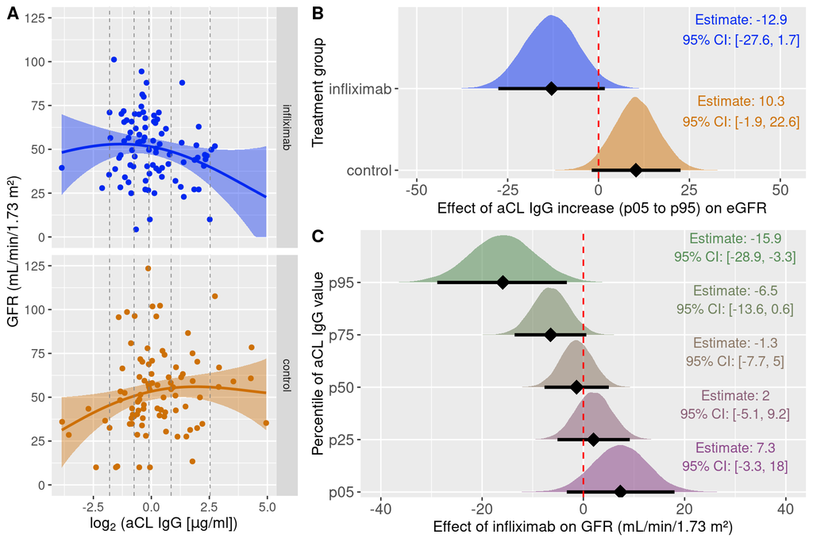

Figure 7: *Supplementary Figure 4*: **Anti-cardiolipin IgG modulates the effect of infliximab on estimated glomerular filtration rate (eGFR).** (**A**) Predicted eGFR by anti-cardiolipin IgG for infliximab (upper) and control (lower) groups, with covariates held at their sample means. Shaded regions represent 95% credible intervals; dashed lines indicate the 5th, 25th, 50th, 75th, and 95th percentiles of cardiolipin levels. (**B**) Posterior distribution of the estimated change in eGFR when anti-cardiolipin IgG increases from the 5th to the 95th sample percentile. (**C**) Posterior distribution of the effect of infliximab on eGFR across anti-cardiolipin IgG percentiles. Results are from a multivariable Bayesian robust regression with B-splines.

```r
plotac <- 'sup_figure_4'
path <- "gitignore/figures"


fig <- cowplot::plot_grid(fig_b, fig_c,
  rel_heights = c(0.7, 1),
  labels = c("B", "C"),
  ncol = 1
)

assign(
  plotac,
  cowplot::plot_grid(
    fig_a, fig,
    rel_widths = c(0.6, 1),
    labels = c("A", "")
  )
)

get(plotac)

if (file.exists(paste0(path, "/", plotac)) == FALSE) {
  ggsave(
    path = paste0(path),
    filename = plotac,
    device = "pdf",
    width = 9,
    height = 6
  )
}
```

## 9.2 by GPL_BC - nonimputed failures

This sensitivity analysis aims to evaluate whether the results are consistent when the eGFR definition is modified — using the last available value before graft failure within two years of follow-up, instead of imputing a fixed value of 10 for all failures

### 9.2.1 Priors

**Open code**

```r
GFR_sd <- sd(data_model_priorImpute$GFR_MDRD_2)
GFR_sd
## [1] 20.65503
```

#### 9.2.1.1 Main effects model

**Open code**

```r
priors_main <- c(
  create_prior("GPL_BC_log2",
    GFR_sd*(2*GFR_sd) / sd(data_model_priorImpute$GPL_BC_log2, na.rm = TRUE),
    coef = "GPL_BC_log2"
  ),
   create_prior("IHLA_MMM5",
    (2*GFR_sd) / sd(data_model_priorImpute$HLA_MM, na.rm = TRUE),
    coef = "IHLA_MMM5"
  ),
  create_prior("IKDPIM50",
    (2*GFR_sd) / sd(data_model_priorImpute$KDPI, na.rm = TRUE),
    coef = "IKDPIM50"
  ),
  create_prior("Irec_ageM50",
    (2*GFR_sd) / sd(data_model_priorImpute$rec_age, na.rm = TRUE),
    coef = "Irec_ageM50"
),
  create_prior("ICITM15",
    (2*GFR_sd) / sd(data_model_priorImpute$CIT, na.rm = TRUE),
    coef = "ICITM15"
  ),
  create_prior("male_sex",
    4*GFR_sd,
    coef = "male_sex"
  ),
  create_prior("perfusion_event",
    4*GFR_sd,
    coef = "perfusion_event"
  ),
  create_prior("male_sex_donor",
    4*GFR_sd,
    coef = "male_sex_donor"
  ),
  create_prior("infliximab",
    4*GFR_sd,
    coef = "infliximab"
  ),
  set_prior(paste0("normal(", mean(data_model_priorImpute$GFR_MDRD_2), ", 200)"),
    class = "Intercept"
  )
)
```

#### 9.2.1.2 Non-linear penalized interaction model

**Open code**

```r
priors_interaction_pnl <- c(
  create_prior("Irec_ageM50",
               (2*GFR_sd) / sd(data_model_priorImpute$rec_age, na.rm = TRUE),
    coef = "Irec_ageM50"),
  create_prior("IHLA_MMM5",
               (2*GFR_sd) / sd(data_model_priorImpute$HLA_MM, na.rm = TRUE),
    coef = "IHLA_MMM5"),
  create_prior("IKDPIM50",
               (2*GFR_sd) / sd(data_model_priorImpute$KDPI, na.rm = TRUE),
    coef = "IKDPIM50"),
  create_prior("ICITM15",
               (2*GFR_sd) / sd(data_model_priorImpute$CIT, na.rm = TRUE),
    coef = "ICITM15"),
  create_prior("male_sex",
    4*GFR_sd,
    coef = "male_sex"),
  create_prior("perfusion_event",
    4*GFR_sd,
    coef = "perfusion_event"),
  create_prior("male_sex_donor",
    4*GFR_sd,
    coef = "male_sex_donor"),

  create_prior("infliximab",
    4*GFR_sd,
    coef = "infliximab"),

 set_prior("student_t(3, 0, 12)", class = "sds",
           coef = 's(GPL_BC_log2, bs = "ps", k = 5)'),

 set_prior("student_t(3, 0, 6)", class = "sds",
           coef = 's(GPL_BC_log2, by = infliximab, bs = "ps", k = 5)'),

  set_prior(paste0("normal(", mean(data_model_priorImpute$GFR_MDRD_2), ", 200)"),
            class = "Intercept")
)
```

### 9.2.2 Models

#### 9.2.2.1 Main effects models

**Open code**

```r
model_GFR_MDRD_2_GPL_BC_main <- run(
  expr = brm_multiple(
    GFR_MDRD_2 ~
      male_sex +
      I(rec_age - 50) +
      male_sex_donor +
      I(KDPI - 50) +
      I(CIT - 15) +
      I(HLA_MM - 5) +
      perfusion_event +
      infliximab +
      GPL_BC_log2,
    family = student(),
    data = data_imputed,
    prior = priors_main,
    backend = "cmdstanr",
    seed = 2025,
    cores = 4, chains = 4,
    iter = 2000, warmup = 1900,
    control = list(adapt_delta = 0.95)
  ),
  path = "gitignore/run/model_GFR_MDRD_2_GPL_BC_main",
  reuse = TRUE
)

summary(model_GFR_MDRD_2_GPL_BC_main, robust = TRUE)
## Warning: Parts of the model have not converged (some Rhats are > 1.05). Be
## careful when analysing the results! We recommend running more iterations and/or
## setting stronger priors.
##  Family: student
##   Links: mu = identity; sigma = identity; nu = identity
## Formula: GFR_MDRD_2 ~ male_sex + I(rec_age - 50) + male_sex_donor + I(KDPI - 50) + I(CIT - 15) + I(HLA_MM - 5) + perfusion_event + infliximab + GPL_BC_log2
##    Data: data_imputed (Number of observations: 177)
##   Draws: 320 chains, each with iter = 2000; warmup = 1900; thin = 1;
##          total post-warmup draws = 32000
##
## Regression Coefficients:
##                 Estimate Est.Error l-95% CI u-95% CI Rhat Bulk_ESS Tail_ESS
## Intercept          53.49      4.03    45.64    61.41 1.02    15993    26757
## male_sex            1.88      3.18    -4.38     8.08 1.01    38010    26941
## Irec_ageM50         0.02      0.15    -0.27     0.30 1.01    36815    27819
## male_sex_donor      1.01      3.17    -5.20     7.19 1.01    37320    27500
## IKDPIM50           -0.24      0.08    -0.39    -0.09 1.00    35494    27775
## ICITM15             0.28      0.22    -0.15     0.72 1.02    10627    25966
## IHLA_MMM5          -0.76      1.08    -2.88     1.33 1.06     3338    17289
## perfusion_event    -6.23      3.39   -12.97     0.51 1.06     3399    13342
## infliximab         -2.48      3.08    -8.56     3.59 1.01    35765    27828
## GPL_BC_log2         0.12      1.10    -2.03     2.26 1.01    38197    27820
##
## Further Distributional Parameters:
##       Estimate Est.Error l-95% CI u-95% CI Rhat Bulk_ESS Tail_ESS
## sigma    18.60      1.30    16.00    21.20 1.00    27749    23012
## nu       17.32     10.08     5.74    52.43 1.00    29322    25293
##
## Draws were sampled using sample(hmc). For each parameter, Bulk_ESS
## and Tail_ESS are effective sample size measures, and Rhat is the potential
## scale reduction factor on split chains (at convergence, Rhat = 1).
prior_summary(model_GFR_MDRD_2_GPL_BC_main)
##                          prior     class            coef group resp dpar nlpar
##                         (flat)         b
##    normal(0, 602.276328897438)         b     GPL_BC_log2
##    normal(0, 5.78975030085778)         b         ICITM15
##    normal(0, 28.5491898394416)         b       IHLA_MMM5
##    normal(0, 2.00556315348783)         b        IKDPIM50
##    normal(0, 82.6201297329089)         b      infliximab
##    normal(0, 3.93663771894749)         b     Irec_ageM50
##    normal(0, 82.6201297329089)         b        male_sex
##    normal(0, 82.6201297329089)         b  male_sex_donor
##    normal(0, 82.6201297329089)         b perfusion_event
##  normal(52.0419774011299, 200) Intercept
##                  gamma(2, 0.1)        nu
##          student_t(3, 0, 19.7)     sigma
##  lb ub  source
##        default
##           user
##           user
##           user
##           user
##           user
##           user
##           user
##           user
##           user
##           user
##   1    default
##   0    default

tr <- round(fixef(model_GFR_MDRD_2_GPL_BC_main, robust = TRUE)[-1, c(1,3,4)], 2)
colnames(tr)[1] <- 'Estimate'
kableExtra::kable(tr)
```

Table 19: Results from multivariable Bayesian robust regression model examining the main effects of predictors, including `infliximab` treatment and log2-transformed anti-cardiolipin IgG (`GPL_BC_log2`), on estimated glomerular filtration rate (eGFR; `GFR_MDRD_2`,). No imputation was applied in cases of graft failure, and no interaction terms were included. `Estimate` represents the estimated change in eGFR per one-unit increase in the predictor. `Q2.5` and `Q97.5`: lower and upper bounds of the 95% credible interval, respectively.

|  | Estimate | Q2.5 | Q97.5 |
| --- | --- | --- | --- |
| male_sex | 1.88 | -4.38 | 8.08 |
| Irec_ageM50 | 0.02 | -0.27 | 0.30 |
| male_sex_donor | 1.01 | -5.20 | 7.19 |
| IKDPIM50 | -0.24 | -0.39 | -0.09 |
| ICITM15 | 0.28 | -0.15 | 0.72 |
| IHLA_MMM5 | -0.76 | -2.88 | 1.33 |
| perfusion_event | -6.23 | -12.97 | 0.51 |
| infliximab | -2.48 | -8.56 | 3.59 |
| GPL_BC_log2 | 0.12 | -2.03 | 2.26 |

#### 9.2.2.2 Non-linear interaction model

**Open code**

```r
model_GFR_MDRD_2_GPL_BC_interaction_NL <- run(
  expr = brm_multiple(
    GFR_MDRD_2 ~
    male_sex +
    I(rec_age - 50) +
    male_sex_donor +
    I(KDPI - 50) +
    I(CIT - 15) +
    I(HLA_MM - 5) +
    perfusion_event +
    infliximab +
    s(GPL_BC_log2, bs = 'ps', k = 5) +
    s(GPL_BC_log2, by = infliximab, bs = 'ps', k = 5),
    family = student(),
    data = data_imputed,
    prior = priors_interaction_pnl,
    backend = "cmdstanr",
    seed = 2025,
    cores = 4, chains = 4,
    iter = 2000, warmup = 1900,
    control = list(adapt_delta = 0.95)
  ),
  path = "gitignore/run/model_GFR_MDRD_2_GPL_BC_interaction_NL",
  reuse = TRUE
)

summary(model_GFR_MDRD_2_GPL_BC_interaction_NL, robust = TRUE)
## Warning: Parts of the model have not converged (some Rhats are > 1.05). Be
## careful when analysing the results! We recommend running more iterations and/or
## setting stronger priors.
##  Family: student
##   Links: mu = identity; sigma = identity; nu = identity
## Formula: GFR_MDRD_2 ~ male_sex + I(rec_age - 50) + male_sex_donor + I(KDPI - 50) + I(CIT - 15) + I(HLA_MM - 5) + perfusion_event + infliximab + s(GPL_BC_log2, bs = "ps", k = 5) + s(GPL_BC_log2, by = infliximab, bs = "ps", k = 5)
##    Data: data_imputed (Number of observations: 177)
##   Draws: 320 chains, each with iter = 2000; warmup = 1900; thin = 1;
##          total post-warmup draws = 32000
##
## Smoothing Spline Hyperparameters:
##                               Estimate Est.Error l-95% CI u-95% CI Rhat
## sds(sGPL_BC_log2_1)              10.47      6.87     1.01    34.89 1.01
## sds(sGPL_BC_log2infliximab_1)     4.17      3.86     0.20    19.45 1.00
##                               Bulk_ESS Tail_ESS
## sds(sGPL_BC_log2_1)              16663    12838
## sds(sGPL_BC_log2infliximab_1)    34184    17036
##
## Regression Coefficients:
##                           Estimate Est.Error l-95% CI u-95% CI Rhat Bulk_ESS
## Intercept                    54.53      3.90    46.78    62.26 1.01    18178
## male_sex                      1.18      3.07    -4.93     7.30 1.01    47019
## Irec_ageM50                   0.02      0.15    -0.26     0.31 1.01    45913
## male_sex_donor               -0.52      3.16    -6.67     5.73 1.01    47158
## IKDPIM50                     -0.25      0.08    -0.41    -0.10 1.01    42963
## ICITM15                       0.29      0.21    -0.14     0.71 1.02    11961
## IHLA_MMM5                    -0.92      1.06    -3.03     1.17 1.06     3210
## perfusion_event              -5.89      3.32   -12.43     0.68 1.05     4191
## infliximab                   -1.23     80.69  -159.19   157.37 1.01    14948
## sGPL_BC_log2_1               14.87     14.78   -15.57    55.53 1.01    24535
## sGPL_BC_log2:infliximab_1   -15.78     46.50  -106.59    74.82 1.01    15218
## sGPL_BC_log2:infliximab_2    12.64     28.58   -44.34    68.43 1.01    15240
##                           Tail_ESS
## Intercept                    27334
## male_sex                     26089
## Irec_ageM50                  27422
## male_sex_donor               27864
## IKDPIM50                     27758
## ICITM15                      26006
## IHLA_MMM5                    14291
## perfusion_event              21697
## infliximab                   20385
## sGPL_BC_log2_1               19710
## sGPL_BC_log2:infliximab_1    21475
## sGPL_BC_log2:infliximab_2    21127
##
## Further Distributional Parameters:
##       Estimate Est.Error l-95% CI u-95% CI Rhat Bulk_ESS Tail_ESS
## sigma    18.07      1.32    15.41    20.67 1.01    32835    24576
## nu       15.88      9.41     5.26    50.45 1.00    35140    26447
##
## Draws were sampled using sample(hmc). For each parameter, Bulk_ESS
## and Tail_ESS are effective sample size measures, and Rhat is the potential
## scale reduction factor on split chains (at convergence, Rhat = 1).
prior_summary(model_GFR_MDRD_2_GPL_BC_interaction_NL)
##                          prior     class
##                         (flat)         b
##    normal(0, 5.78975030085778)         b
##    normal(0, 28.5491898394416)         b
##    normal(0, 2.00556315348783)         b
##    normal(0, 82.6201297329089)         b
##    normal(0, 3.93663771894749)         b
##    normal(0, 82.6201297329089)         b
##    normal(0, 82.6201297329089)         b
##    normal(0, 82.6201297329089)         b
##                         (flat)         b
##                         (flat)         b
##                         (flat)         b
##  normal(52.0419774011299, 200) Intercept
##                  gamma(2, 0.1)        nu
##          student_t(3, 0, 19.7)       sds
##            student_t(3, 0, 12)       sds
##             student_t(3, 0, 6)       sds
##          student_t(3, 0, 19.7)     sigma
##                                               coef group resp dpar nlpar lb ub
##
##                                            ICITM15
##                                          IHLA_MMM5
##                                           IKDPIM50
##                                         infliximab
##                                        Irec_ageM50
##                                           male_sex
##                                     male_sex_donor
##                                    perfusion_event
##                                     sGPL_BC_log2_1
##                          sGPL_BC_log2:infliximab_1
##                          sGPL_BC_log2:infliximab_2
##
##                                                                           1
##                                                                           0
##                   s(GPL_BC_log2, bs = "ps", k = 5)                        0
##  s(GPL_BC_log2, by = infliximab, bs = "ps", k = 5)                        0
##                                                                           0
##        source
##       default
##          user
##          user
##          user
##          user
##          user
##          user
##          user
##          user
##  (vectorized)
##  (vectorized)
##  (vectorized)
##          user
##       default
##       default
##          user
##          user
##       default

tr2 <- round(fixef(model_GFR_MDRD_2_GPL_BC_interaction_NL,
                       robust = TRUE)[-c(1,9:12), c(1,3,4)], 2)

antibody_seq <- quantile(data_model_priorImpute$GPL_BC_log2,
                         probs = c(0.05, 0.95))

asl <- length(antibody_seq)
quant_dif <- antibody_seq[2] - antibody_seq[1]

data_prediction <- data.frame(
    male_sex = rep(mmale_sex, 2*length(antibody_seq)),
  `male_sex_donor` = rep(mmale_sex_donor, 2*length(antibody_seq)),
  `perfusion_event` = rep(mperfusion_event, 2*length(antibody_seq)),
  `infliximab` = c(rep(0, length(antibody_seq)), rep(1, length(antibody_seq))),
  `rec_age` = rep(mrec_age, 2*length(antibody_seq)),
  `KDPI` = rep(mKDPI, 2*length(antibody_seq)),
  `CIT` = rep(mCIT, 2*length(antibody_seq)),
  `HLA_MM` = rep(mHLA_MM, 2*length(antibody_seq)),
  `GPL_BC_log2` = c(antibody_seq, antibody_seq)
  )

tr <-  posterior_epred(
    model_GFR_MDRD_2_GPL_BC_interaction_NL,
    newdata = data_prediction)

prediction_ctrl <- tr[, c(1:asl)]
prediction_infliximab <- tr[, c((asl+1):(asl*2))]

## get Estimate for infliximab effect across antibody values
prediction <- (
  prediction_infliximab-
     prediction_ctrl
  ) %>% data.frame()

names(prediction) <- c('p05', 'p95')

infliximab_GPL_BC_log2_int <- quantile(
  (prediction$p95 - prediction$p05)/scaling_unit,
         probs = c(0.5, 1/40, 39/40))

tr2 <- rbind(tr2, round(infliximab_GPL_BC_log2_int, 2))
row.names(tr2)[8] <- 'infliximab:GPL_BC_log2'
kableExtra::kable(tr2)
```

Table 20: Results from a multivariable Bayesian robust regression model incorporating a non-linear interaction between anti-cardiolipin IgG (`GPL_BC_log2`) and `infliximab` treatment on estimated glomerular filtration rate (`GFR_MDRD_2`), while accounting for other covariates. No imputation was applied in cases of graft failure (the last eGFR value prior graft failure or death was used). `Estimate` represents the estimated change in eGFR per one-unit increase in the predictor. The last row (`infliximab:GPL_BC_log2`) reports the difference in infliximab’s treatment effect at the 95th versus the 5th percentile of anti-cardiolipin IgG, quantifying the interaction effect. `Q2.5` and `Q97.5`: lower and upper bounds of the 95% credible interval, respectively.

|  | Estimate | Q2.5 | Q97.5 |
| --- | --- | --- | --- |
| male_sex | 1.18 | -4.93 | 7.30 |
| Irec_ageM50 | 0.02 | -0.26 | 0.31 |
| male_sex_donor | -0.52 | -6.67 | 5.73 |
| IKDPIM50 | -0.25 | -0.41 | -0.10 |
| ICITM15 | 0.29 | -0.14 | 0.71 |
| IHLA_MMM5 | -0.92 | -3.03 | 1.17 |
| perfusion_event | -5.89 | -12.43 | 0.68 |
| infliximab:GPL_BC_log2 | -22.04 | -40.46 | -3.95 |

### 9.2.3 Visualisation - penalized non-linear effect

Extract posterior draws

**Open code**

```r
antibody_perc <- quantile(data_model_priorImpute$GPL_BC_log2,
                           probs = c(0, 0.02, 0.05, 0.25, 0.5, 0.75, 0.95, 0.98, 1))

antibody_seq <- seq(antibody_perc[1],
                      antibody_perc[length(antibody_perc)],
                      length.out = 101)

## create prediction
data_prediction <- data.frame(
    male_sex = rep(mmale_sex, 2*length(antibody_seq)),
  `male_sex_donor` = rep(mmale_sex_donor, 2*length(antibody_seq)),
  `perfusion_event` = rep(mperfusion_event, 2*length(antibody_seq)),
  `infliximab` = c(rep(0, length(antibody_seq)), rep(1, length(antibody_seq))),
  `rec_age` = rep(mrec_age, 2*length(antibody_seq)),
  `KDPI` = rep(mKDPI, 2*length(antibody_seq)),
  `CIT` = rep(mCIT, 2*length(antibody_seq)),
  `HLA_MM` = rep(mHLA_MM, 2*length(antibody_seq)),
  `GPL_BC_log2` = c(antibody_seq, antibody_seq)
  )

prediction <- data.frame(
  posterior_epred(
    model_GFR_MDRD_2_GPL_BC_interaction_NL,
    newdata = data_prediction) %>% posterior_summary(
      robust = TRUE
      ) %>% data.frame() %>% select(-Est.Error),
  group = factor(if_else(data_prediction$infliximab == 1, 'infliximab', 'control')),
  GPL_BC_log2 = data_prediction$GPL_BC_log2)
```

Figure A

**Open code**

```r
cole <- c('#CD7006', '#0028F0')

fig_a <- prediction %>%
  mutate(group = factor(group, levels = c("infliximab", "control")),
         `Q2.5` = if_else(`Q2.5` < 0, 0, `Q2.5`)) %>%
  ggplot(aes(x = GPL_BC_log2, y = Estimate, col = group, fill = group)) +
  geom_line(aes(y = Estimate), linewidth = 1) +
  scale_y_continuous(limits = c(0, 125),
                      breaks = c(seq(0, 125, by = 25))) +

  geom_ribbon(aes(ymin = `Q2.5`, ymax = `Q97.5`),
               alpha = 0.4,  color = NA) +

  geom_point(data = data_model_priorImpute,
             aes(x = GPL_BC_log2, y = GFR_MDRD_2, col = group, fill = group)) +

  labs(x = expression(log[2]~"(aCL IgG ["*mu*"g/ml])"),
       y = "GFR (mL/min/1.73 m²)") +

  scale_color_manual(values = cole,
                       name = "group",
                       breaks = c('control', 'infliximab'),
                       labels = c('control', 'infliximab')) +

  scale_fill_manual(values = cole,
                       name = "group",
                       breaks = c('control', 'infliximab'),
                       labels = c('control', 'infliximab')) +

  facet_grid(rows = vars(group)) +

  theme(axis.text=element_text(size = 10),
        axis.title=element_text(size = 12),
        strip.text.x = element_text(size = 12),
        legend.position = "none") +

  geom_vline(xintercept = antibody_perc[3:7], linetype = 2,
                            color = "grey50", size = 0.3)
```

Figure B

**Open code**

```r
antibody_seq <- antibody_perc[c(3, 7)]
antibody_seq
##        5%       95%
## -1.801668  2.531821

data_prediction <- data.frame(
   male_sex = rep(mmale_sex, 2*length(antibody_seq)),
  `male_sex_donor` = rep(mmale_sex_donor, 2*length(antibody_seq)),
  `perfusion_event` = rep(mperfusion_event, 2*length(antibody_seq)),
  `infliximab` = c(rep(0, length(antibody_seq)), rep(1, length(antibody_seq))),
  `rec_age` = rep(mrec_age, 2*length(antibody_seq)),
  `KDPI` = rep(mKDPI, 2*length(antibody_seq)),
  `CIT` = rep(mCIT, 2*length(antibody_seq)),
  `HLA_MM` = rep(mHLA_MM, 2*length(antibody_seq)),
  `GPL_BC_log2` = c(antibody_seq, antibody_seq)
  )

tr <-  posterior_epred(
    model_GFR_MDRD_2_GPL_BC_interaction_NL,
    newdata = data_prediction)

tr_ctrl <- (tr[,c(ncol(tr)/2)] - tr[,c(1)])
tr_infliximab <- (tr[,c(ncol(tr))] - tr[,c(ncol(tr)/2)+1])

post_fix <- data.frame(
  b_GPL_BC_log2 = tr_ctrl,
  b_GPL_BC_log2_infliximab = tr_infliximab
)

tr <- post_fix %>%
  mutate(control = b_GPL_BC_log2,
         infliximab = b_GPL_BC_log2_infliximab) %>%
  select(control, infliximab) %>%
  data.frame()

CIS <- sapply(
  tr,
  function(p) quantile(p, probs = c(1/40, 39/40, 0.5, 1e-3, 1-1e-3))
  ) %>%
  round(1)

CIS
##       control infliximab
## 2.5%     -2.7      -27.7
## 97.5%    20.8        1.3
## 50%       9.0      -13.1
## 0.1%     -9.1      -36.6
## 99.9%    27.7        9.7

xpos <- 39.2

fig_b <- tr %>%
  pivot_longer(values_to = 'value',
               cols = c('control', 'infliximab'),
               names_to = 'group') %>%
  ggplot(aes(x = value, y = group, fill = group)) +

  stat_halfeye(.width = c(0.95), slab_alpha=0.5,
               linewidth = 5,
               shape = 18,
               point_size = 5,
               normalize = "groups",
               p_limits = c(1e-3, 1-1e-3)) +

    labs(x = 'Effect of aCL IgG increase (p05 to p95) on eGFR',
         y = 'Treatment group') +

  scale_fill_manual(values = cole,
                       name = "Treatment group",
                       breaks = c('control', 'infliximab'),
                       labels = c('control', 'infliximab')) +

  scale_y_discrete(expand = expansion(add = 0.1)) +
  coord_cartesian(xlim = c(-50, 52)) +

  geom_vline(xintercept = 0, linetype = 2,
                color = "red", size = 0.6) +

  theme(axis.text = element_text(size = 12),
        axis.title = element_text(size = 12)) +

  theme(legend.position = "none") +

  annotate("text",  x = xpos, y = 2.85 ,
           label = paste0("Estimate: ", CIS[3,2]),
           color = cole[2] ) +

  annotate("text",  x = xpos, y = 1.85 ,
           label = paste0("Estimate: ", CIS[3,1]),
           color = cole[1] ) +

  annotate("text",  x = xpos, y = 2.6 ,
           label = paste0("95% CI: [", CIS[1,2], ", ", CIS[2,2], "]"),
           color = cole[2] ) +

  annotate("text",  x = xpos, y = 1.6 ,
           label = paste0("95% CI: [", CIS[1,1], ", ", CIS[2,1], "]"),
           color = cole[1] )
```

Figure C

**Open code**

```r
cole <- c("#8B4789", "#8B5F77", "#8B7765", "#6F815C", "#548B54")
xpos <- 30

antibody_seq <- antibody_perc[c(3, 4, 5, 6, 7)]

asl <- length(antibody_seq)

data_prediction <- data.frame(
    male_sex = rep(mmale_sex, 2*length(antibody_seq)),
  `male_sex_donor` = rep(mmale_sex_donor, 2*length(antibody_seq)),
  `perfusion_event` = rep(mperfusion_event, 2*length(antibody_seq)),
  `infliximab` = c(rep(0, length(antibody_seq)), rep(1, length(antibody_seq))),
  `rec_age` = rep(mrec_age, 2*length(antibody_seq)),
  `KDPI` = rep(mKDPI, 2*length(antibody_seq)),
  `CIT` = rep(mCIT, 2*length(antibody_seq)),
  `HLA_MM` = rep(mHLA_MM, 2*length(antibody_seq)),
  `GPL_BC_log2` = c(antibody_seq, antibody_seq)
  )

tr <-  posterior_epred(
    model_GFR_MDRD_2_GPL_BC_interaction_NL,
    newdata = data_prediction)

prediction_ctrl <- tr[, c(1:asl)]

prediction_infliximab <- tr[, c((asl+1):(asl*2))]

prediction <- (
  prediction_infliximab-
     prediction_ctrl
  ) %>% data.frame()


names(prediction) <- c('p05', 'p25', 'p50', 'p75', 'p95')

CIS <- sapply(
  prediction,
  function(p) quantile(p, probs = c(1/40, 39/40, 0.5, 1e-3, 1-1e-3))
  ) %>%
  round(1)

CIS
##         p05  p25   p50   p75   p95
## 2.5%   -3.9 -5.5  -8.0 -13.5 -28.2
## 97.5%  16.7  8.3   4.4   0.2  -3.5
## 50%     6.4  1.4  -1.8  -6.6 -15.7
## 0.1%  -10.0 -9.6 -11.5 -17.7 -35.9
## 99.9%  22.8 12.4   8.1   4.3   3.5

fig_c <- prediction %>%
  pivot_longer(values_to = 'value',
               cols = c('p05', 'p25', 'p50', 'p75', 'p95'),
               names_to = 'GPL_BC_percentile') %>%

  ggplot(aes(y = GPL_BC_percentile, x = value, fill = GPL_BC_percentile)) +

  stat_halfeye(.width = c(0.95), slab_alpha = 0.55,
               linewidth = 5,
               shape = 18,
               point_size = 5,
               normalize = "groups",
               p_limits = c(1e-3, 1-1e-3)) +

  labs(x = "Effect of infliximab on GFR (mL/min/1.73 m²)",
         y = 'Percentile of aCL IgG value') +

  scale_fill_manual(values = cole,
                       name = "Percentile of aCL IgG value",
                       breaks = c('p05', 'p25', 'p50', 'p75', 'p95'),
                       labels = c('p05', 'p25', 'p50', 'p75', 'p95')) +

  coord_cartesian(xlim = c(-40, 40)) +
  scale_y_discrete(expand = expansion(add = 0.1)) +


  geom_vline(xintercept = 0, linetype = 2,
                color = "red", size = 0.6) +

  theme(axis.text = element_text(size = 12),
        axis.title = element_text(size = 12)) +

  theme(legend.position = "none") +


  annotate("text",  x = xpos, y = 5.85 ,
           label = paste0("Estimate: ", CIS[3,5]),
           color = cole[5] ) +

  annotate("text",  x = xpos, y = 4.85,
           label = paste0("Estimate: ", CIS[3,4]),
           color = cole[4] ) +

  annotate("text",  x = xpos, y = 3.85,
           label = paste0("Estimate: ", CIS[3,3]),
           color = cole[3] ) +

  annotate("text",  x = xpos, y = 2.85,
           label = paste0("Estimate: ", CIS[3,2]),
           color = cole[2] ) +

  annotate("text",  x = xpos, y = 1.85,
           label = paste0("Estimate: ", CIS[3,1]),
           color = cole[1] ) +

  annotate("text",  x = xpos, y = 5.5 ,
           label = paste0("95% CI: [", CIS[1,5], ", ", CIS[2,5], "]"),
           color = cole[5] ) +

  annotate("text",  x = xpos, y = 4.5 ,
           label = paste0("95% CI: [", CIS[1,4], ", ", CIS[2,4], "]"),
           color = cole[4] ) +

  annotate("text",  x = xpos, y = 3.5 ,
           label = paste0("95% CI: [", CIS[1,3], ", ", CIS[2,3], "]"),
           color = cole[3] ) +

  annotate("text",  x = xpos, y = 2.5 ,
           label = paste0("95% CI: [", CIS[1,2], ", ", CIS[2,2], "]"),
           color = cole[2] ) +

  annotate("text",  x = xpos, y = 1.5 ,
           label = paste0("95% CI: [", CIS[1,1], ", ", CIS[2,1], "]"),
           color = cole[1] )
```

#### 9.2.3.1 Figure merged

**Open code**

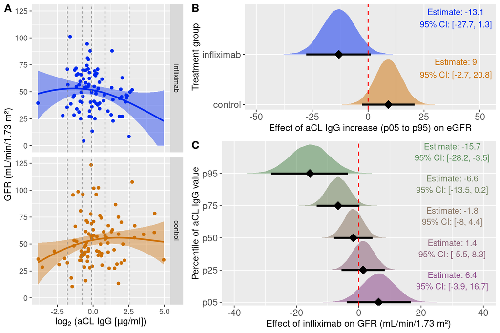

Figure 8: *Supplemetary Figure 7*: **Anti-cardiolipin IgG modulates the effect of infliximab on estimated glomerular filtration rate (eGFR); unlike in Supplementary Figure 4, no imputation was applied in cases of graft failure.** (**A**) Predicted eGFR by anti-cardiolipin IgG for infliximab (upper) and control (lower) groups, with covariates held at their sample means. Shaded regions represent 95% credible intervals; dashed lines indicate the 5th, 25th, 50th, 75th, and 95th percentiles of cardiolipin levels. (**B**) Posterior distribution of the estimated change in eGFR when anti-cardiolipin IgG increases from the 5th to the 95th sample percentile. (**C**) Posterior distribution of the effect of infliximab on eGFR across anti-cardiolipin IgG percentiles. Results are from a multivariable Bayesian robust regression with B-splines.

```r
plotac <- 'sup_figure_7'
path <- "gitignore/figures"


fig <- cowplot::plot_grid(fig_b, fig_c,
  rel_heights = c(0.7, 1),
  labels = c("B", "C"),
  ncol = 1
)

assign(
  plotac,
  cowplot::plot_grid(
    fig_a, fig,
    rel_widths = c(0.6, 1),
    labels = c("A", "")
  )
)

get(plotac)

if (file.exists(paste0(path, "/", plotac)) == FALSE) {
  ggsave(
    path = paste0(path),
    filename = plotac,
    device = "pdf",
    width = 9,
    height = 6
  )
}
```

## 9.3 by MPL_BC

**Open code**

```r
GFR_sd <- sd(data_model_priorImpute$GFR_MDRD_3)
GFR_sd
## [1] 21.17099
```

### 9.3.1 Priors

#### 9.3.1.1 Main effects model

**Open code**

```r
priors_main <- c(
  create_prior("IMPL_BC_log2M2",
    (2*GFR_sd) / sd(data_model_priorImpute$MPL_BC_log2, na.rm = TRUE),
    coef = "IMPL_BC_log2M2"
  ),
   create_prior("IHLA_MMM5",
    (2*GFR_sd) / sd(data_model_priorImpute$HLA_MM, na.rm = TRUE),
    coef = "IHLA_MMM5"
  ),
  create_prior("IKDPIM50",
    (2*GFR_sd) / sd(data_model_priorImpute$KDPI, na.rm = TRUE),
    coef = "IKDPIM50"
  ),
  create_prior("Irec_ageM50",
    (2*GFR_sd) / sd(data_model_priorImpute$rec_age, na.rm = TRUE),
    coef = "Irec_ageM50"
),
  create_prior("ICITM15",
    (2*GFR_sd) / sd(data_model_priorImpute$CIT, na.rm = TRUE),
    coef = "ICITM15"
  ),
  create_prior("male_sex",
    4*GFR_sd,
    coef = "male_sex"
  ),
  create_prior("perfusion_event",
    4*GFR_sd,
    coef = "perfusion_event"
  ),
  create_prior("male_sex_donor",
    4*GFR_sd,
    coef = "male_sex_donor"
  ),
  create_prior("infliximab",
    4*GFR_sd,
    coef = "infliximab"
  ),
  set_prior(paste0("normal(", mean(data_model_priorImpute$GFR_MDRD_3), ", 200)"),
    class = "Intercept"
  )
)
```

#### 9.3.1.2 Non-linear penalized interaction model

**Open code**

```r
priors_interaction_pnl <- c(
  create_prior("Irec_ageM50",
               (2*GFR_sd) / sd(data_model_priorImpute$rec_age, na.rm = TRUE),
    coef = "Irec_ageM50"),
  create_prior("IHLA_MMM5",
               (2*GFR_sd) / sd(data_model_priorImpute$HLA_MM, na.rm = TRUE),
    coef = "IHLA_MMM5"),
  create_prior("IKDPIM50",
               (2*GFR_sd) / sd(data_model_priorImpute$KDPI, na.rm = TRUE),
    coef = "IKDPIM50"),
  create_prior("ICITM15",
               (2*GFR_sd) / sd(data_model_priorImpute$CIT, na.rm = TRUE),
    coef = "ICITM15"),
  create_prior("male_sex",
    4*GFR_sd,
    coef = "male_sex"),
  create_prior("perfusion_event",
    4*GFR_sd,
    coef = "perfusion_event"),
  create_prior("male_sex_donor",
    4*GFR_sd,
    coef = "male_sex_donor"),

  create_prior("infliximab",
    4*GFR_sd,
    coef = "infliximab"),

 set_prior("student_t(3, 0, 12)", class = "sds",
           coef = 's(I(MPL_BC_log2 - 2), bs = "ps", k = 5)'),

 set_prior("student_t(3, 0, 6)", class = "sds",
           coef = 's(I(MPL_BC_log2 - 2), by = infliximab, bs = "ps", k = 5)'),

  set_prior(paste0("normal(", mean(data_model_priorImpute$GFR_MDRD_3), ", 200)"),
            class = "Intercept")
)
```